# Part I - How Trip Data Attributes and Features Affect Duration

## Introduction

> This data collection contains rider-specific information from a bike-sharing system serving the whole San Francisco Bay area. The dataset includes details on about 183,000 rides. Features include duration (measured in seconds) and other characteristics like gender, the user type (customer or subscriber), and date and time. The member's birth year, the names of the start and finish stations, the longitude and latitude of each station, and the unique IDs of each station provide further details.

| **Column Name** | **Description** |
| --- | --- |
| `duration_sec` | Duration of the trip in seconds. |
| `start_time` | Start time of the trip. |
| `end_time` | End time of the trip. |
| `start_station_id` | ID of the start station. |
| `start_station_name` | Name of the start station. |
| `start_station_latitude` | Latitude of the start station. |
| `start_station_longitude` | Longitude of the start station. |
| `end_station_id` | ID of the end station. |
| `end_station_name` | Name of the end station. |
| `end_station_latitude` | Latitude of the end station. |
| `end_station_longitude` | Longitude of the end station. |
| `bike_id` | ID of the bike. |
| `user_type` | Type of user (Customer or Subscriber). |
| `member_birth_year` | Birth year of the member. |
| `member_gender` | Gender of the member. |
| `bike_share_for_all_trip` | Indicates if the bike share program is for all trips. |

## Preliminary Wrangling

```python
# import all packages and set plots to be embedded inline
import numpy as np
import pandas as pd
import matplotlib.pyplot as plt
import seaborn as sb

%matplotlib inline
```

```python
bike_data_df = pd.read_csv("./201902-fordgobike-tripdata.csv")
```

```python
#Print the name of the columns for the books data
print("The columns for the books dataset are:")
print(bike_data_df.columns.to_list())
```

[output not shown]

```python
#Display some sample from the books data
bike_data_df.sample(20,random_state=20)
```

|  | duration_sec | start_time | end_time | start_station_id | start_station_name | start_station_latitude | start_station_longitude | end_station_id | end_station_name | end_station_latitude | end_station_longitude | bike_id | user_type | member_birth_year | member_gender | bike_share_for_all_trip |
| --- | --- | --- | --- | --- | --- | --- | --- | --- | --- | --- | --- | --- | --- | --- | --- | --- |
| 179342 | 291 | 2019-02-01 14:17:50.4280 | 2019-02-01 14:22:42.2650 | 10.0 | Washington St at Kearny St | 37.795393 | -122.404770 | 16.0 | Steuart St at Market St | 37.794130 | -122.394430 | 5404 | Subscriber | 1995.0 | Male | No |
| 80515 | 1502 | 2019-02-18 15:10:04.6900 | 2019-02-18 15:35:07.5800 | 92.0 | Mission Bay Kids Park | 37.772301 | -122.393028 | 54.0 | Alamo Square (Steiner St at Fulton St) | 37.777547 | -122.433274 | 5030 | Customer | NaN | NaN | No |
| 39652 | 476 | 2019-02-23 07:43:24.2190 | 2019-02-23 07:51:20.4910 | 31.0 | Raymond Kimbell Playground | 37.783813 | -122.434559 | 85.0 | Church St at Duboce Ave | 37.770083 | -122.429156 | 4615 | Subscriber | NaN | NaN | No |
| 104144 | 703 | 2019-02-14 08:50:12.5550 | 2019-02-14 09:01:56.1770 | 211.0 | Broadway at 40th St | 37.827757 | -122.256716 | 181.0 | Grand Ave at Webster St | 37.811377 | -122.265192 | 1077 | Customer | 1983.0 | Female | No |
| 161514 | 361 | 2019-02-05 14:41:33.1260 | 2019-02-05 14:47:34.3700 | 47.0 | 4th St at Harrison St | 37.780955 | -122.399749 | 3.0 | Powell St BART Station (Market St at 4th St) | 37.786375 | -122.404904 | 5280 | Subscriber | 1989.0 | Male | No |
| 11707 | 997 | 2019-02-27 18:11:54.2060 | 2019-02-27 18:28:31.6510 | 3.0 | Powell St BART Station (Market St at 4th St) | 37.786375 | -122.404904 | 29.0 | O'Farrell St at Divisadero St | 37.782405 | -122.439446 | 4608 | Subscriber | 1985.0 | Female | No |
| 7984 | 678 | 2019-02-28 08:37:30.0340 | 2019-02-28 08:48:48.3200 | 74.0 | Laguna St at Hayes St | 37.776435 | -122.426244 | 30.0 | San Francisco Caltrain (Townsend St at 4th St) | 37.776598 | -122.395282 | 6527 | Subscriber | 1981.0 | Male | No |
| 116588 | 991 | 2019-02-12 07:28:51.5760 | 2019-02-12 07:45:22.7010 | 95.0 | Sanchez St at 15th St | 37.766219 | -122.431060 | 355.0 | 23rd St at Tennessee St | 37.755367 | -122.388795 | 5299 | Subscriber | 1995.0 | Female | No |
| 131597 | 307 | 2019-02-09 11:51:30.4310 | 2019-02-09 11:56:37.8120 | 28.0 | The Embarcadero at Bryant St | 37.787168 | -122.388098 | 66.0 | 3rd St at Townsend St | 37.778742 | -122.392741 | 5224 | Customer | 1979.0 | Female | No |
| 6933 | 653 | 2019-02-28 09:28:37.4370 | 2019-02-28 09:39:30.6080 | 15.0 | San Francisco Ferry Building (Harry Bridges Pl... | 37.795392 | -122.394203 | 66.0 | 3rd St at Townsend St | 37.778742 | -122.392741 | 5844 | Subscriber | 1973.0 | Male | No |
| 20681 | 1327 | 2019-02-26 11:02:05.7860 | 2019-02-26 11:24:13.6610 | 19.0 | Post St at Kearny St | 37.788975 | -122.403452 | 17.0 | Embarcadero BART Station (Beale St at Market St) | 37.792251 | -122.397086 | 4772 | Subscriber | 1991.0 | Female | No |
| 45840 | 456 | 2019-02-22 11:09:38.3240 | 2019-02-22 11:17:15.0080 | 248.0 | Telegraph Ave at Ashby Ave | 37.855956 | -122.259795 | 256.0 | Hearst Ave at Euclid Ave | 37.875112 | -122.260553 | 5119 | Subscriber | 1995.0 | Male | No |
| 12575 | 1451 | 2019-02-27 17:09:51.5250 | 2019-02-27 17:34:03.2340 | 81.0 | Berry St at 4th St | 37.775880 | -122.393170 | 368.0 | Myrtle St at Polk St | 37.785434 | -122.419622 | 5338 | Subscriber | 1976.0 | Female | No |
| 148468 | 274 | 2019-02-06 21:55:24.7840 | 2019-02-06 21:59:59.3740 | 100.0 | Bryant St at 15th St | 37.767100 | -122.410662 | 223.0 | 16th St Mission BART Station 2 | 37.764765 | -122.420091 | 5249 | Subscriber | 1987.0 | Male | Yes |
| 56513 | 477 | 2019-02-21 08:58:13.7190 | 2019-02-21 09:06:11.4840 | 64.0 | 5th St at Brannan St | 37.776754 | -122.399018 | 34.0 | Father Alfred E Boeddeker Park | 37.783988 | -122.412408 | 6300 | Subscriber | 1961.0 | Male | Yes |
| 118860 | 749 | 2019-02-11 18:20:53.7930 | 2019-02-11 18:33:23.2860 | 25.0 | Howard St at 2nd St | 37.787522 | -122.397405 | 58.0 | Market St at 10th St | 37.776619 | -122.417385 | 1836 | Subscriber | 1995.0 | Male | No |
| 61892 | 656 | 2019-02-20 17:18:34.5550 | 2019-02-20 17:29:30.5550 | 338.0 | 13th St at Franklin St | 37.803189 | -122.270579 | 197.0 | El Embarcadero at Grand Ave | 37.808848 | -122.249680 | 1207 | Customer | 1982.0 | Female | No |
| 29451 | 627 | 2019-02-25 07:21:31.0010 | 2019-02-25 07:31:58.1280 | 77.0 | 11th St at Natoma St | 37.773507 | -122.416040 | 21.0 | Montgomery St BART Station (Market St at 2nd St) | 37.789625 | -122.400811 | 5852 | Subscriber | 1987.0 | Female | No |
| 137350 | 1143 | 2019-02-08 08:35:31.2980 | 2019-02-08 08:54:35.2520 | 141.0 | Valencia St at Cesar Chavez St | 37.747998 | -122.420219 | 27.0 | Beale St at Harrison St | 37.788059 | -122.391865 | 4737 | Subscriber | 1982.0 | Male | No |
| 67022 | 1186 | 2019-02-20 08:06:57.1310 | 2019-02-20 08:26:43.9470 | 55.0 | Webster St at Grove St | 37.777053 | -122.429558 | 104.0 | 4th St at 16th St | 37.767045 | -122.390833 | 6341 | Customer | 1987.0 | Female | No |

```python
#Print the number of rows and the number of columns
print(f'# of rows {bike_data_df.shape[0]:,} , # of columns {bike_data_df.shape[1]:,}')
```

```
# of rows 183,412 , # of columns 16
```

```python
bike_data_df.describe()
```

|  | duration_sec | start_station_id | start_station_latitude | start_station_longitude | end_station_id | end_station_latitude | end_station_longitude | bike_id | member_birth_year |
| --- | --- | --- | --- | --- | --- | --- | --- | --- | --- |
| count | 183412.000000 | 183215.000000 | 183412.000000 | 183412.000000 | 183215.000000 | 183412.000000 | 183412.000000 | 183412.000000 | 175147.000000 |
| mean | 726.078435 | 138.590427 | 37.771223 | -122.352664 | 136.249123 | 37.771427 | -122.352250 | 4472.906375 | 1984.806437 |
| std | 1794.389780 | 111.778864 | 0.099581 | 0.117097 | 111.515131 | 0.099490 | 0.116673 | 1664.383394 | 10.116689 |
| min | 61.000000 | 3.000000 | 37.317298 | -122.453704 | 3.000000 | 37.317298 | -122.453704 | 11.000000 | 1878.000000 |
| 25% | 325.000000 | 47.000000 | 37.770083 | -122.412408 | 44.000000 | 37.770407 | -122.411726 | 3777.000000 | 1980.000000 |
| 50% | 514.000000 | 104.000000 | 37.780760 | -122.398285 | 100.000000 | 37.781010 | -122.398279 | 4958.000000 | 1987.000000 |
| 75% | 796.000000 | 239.000000 | 37.797280 | -122.286533 | 235.000000 | 37.797320 | -122.288045 | 5502.000000 | 1992.000000 |
| max | 85444.000000 | 398.000000 | 37.880222 | -121.874119 | 398.000000 | 37.880222 | -121.874119 | 6645.000000 | 2001.000000 |

```python
# Print the attributes types for the dataset
print(bike_data_df.dtypes)
```

```
duration_sec                 int64
start_time                  object
end_time                    object
start_station_id           float64
start_station_name          object
start_station_latitude     float64
start_station_longitude    float64
end_station_id             float64
end_station_name            object
end_station_latitude       float64
end_station_longitude      float64
bike_id                      int64
user_type                   object
member_birth_year          float64
member_gender               object
bike_share_for_all_trip     object
dtype: object
```

```python
bike_data_df.info()
```

```
<class 'pandas.core.frame.DataFrame'>
RangeIndex: 183412 entries, 0 to 183411
Data columns (total 16 columns):
 #   Column                   Non-Null Count   Dtype
---  ------                   --------------   -----
 0   duration_sec             183412 non-null  int64
 1   start_time               183412 non-null  object
 2   end_time                 183412 non-null  object
 3   start_station_id         183215 non-null  float64
 4   start_station_name       183215 non-null  object
 5   start_station_latitude   183412 non-null  float64
 6   start_station_longitude  183412 non-null  float64
 7   end_station_id           183215 non-null  float64
 8   end_station_name         183215 non-null  object
 9   end_station_latitude     183412 non-null  float64
 10  end_station_longitude    183412 non-null  float64
 11  bike_id                  183412 non-null  int64
 12  user_type                183412 non-null  object
 13  member_birth_year        175147 non-null  float64
 14  member_gender            175147 non-null  object
 15  bike_share_for_all_trip  183412 non-null  object
dtypes: float64(7), int64(2), object(7)
memory usage: 22.4+ MB
```

> From the previous output we can see that the type of the start_time and end_time columns are object and need to be convert to datetime type

> The start_station_id, end_station_id, member_birth_year columns are float and needs to be converted to int

> The user_type column should be convert to category

> The bike_share_for_all_trip column should be convert to bool

```python
#Print the count of the null value in each feature
print("The count of null values for each feature:")
print(bike_data_df.isnull().sum())
```

[output not shown]

```python
#Print the count of the duplicates row in the data set
print(f'The number of duplicates rows are: {bike_data_df.duplicated().sum()}',)
```

```
The number of duplicates rows are: 0
```

## Data Cleaning

```python
#Remove the missing values from the dataset
bike_data_df.dropna(inplace=True)
```

```python
#Define a function to convert the types of the attributes
def convert_data_type(df,column_To_convert):
    for key,type in column_To_convert.items():
        df[key] = df[key].astype(type)
```

```python
#Define the column that needed to convert the data type of them and then call convert_data_type function to convert them
column_To_convert={"member_birth_year":"int64","start_station_id":"int64","end_station_id":"int64","user_type":"category" ,"bike_share_for_all_trip":"bool"}
convert_data_type(bike_data_df,column_To_convert)
```

```python
#Define a function to convert the data type to datetime
def convert_date_time_type(df,key):
    df[key]=pd.to_datetime(df[key])
```

```python
#Call the function convert_date_time_type to convert the attributes ScheduledDay and AppointmentDay from object to datetime
convert_date_time_type(bike_data_df,"start_time")
convert_date_time_type(bike_data_df,"end_time")
```

```python
print(bike_data_df.dtypes)
```

```
duration_sec                        int64
start_time                 datetime64[ns]
end_time                   datetime64[ns]
start_station_id                    int64
start_station_name                 object
start_station_latitude            float64
start_station_longitude           float64
end_station_id                      int64
end_station_name                   object
end_station_latitude              float64
end_station_longitude             float64
bike_id                             int64
user_type                        category
member_birth_year                   int64
member_gender                      object
bike_share_for_all_trip              bool
dtype: object
```

### What is the structure of your dataset?

> The dataset has 183,412 rows of data that describe bike trips and the data set contain 16 columns that are ['duration_sec', 'start_time', 'end_time', 'start_station_id', 'start_station_name', 'start_station_latitude', 'start_station_longitude', 'end_station_id', 'end_station_name', 'end_station_latitude', 'end_station_longitude', 'bike_id', 'user_type', 'member_birth_year', 'member_gender', 'bike_share_for_all_trip'] The types of the attributes are int, bool, float, object, dateTime and category

### What is/are the main feature(s) of interest in your dataset?

> The duration_sec attribute and the user_type attribute are the features that I'm aiming to study for this dataset

### What features in the dataset do you think will help support your investigation into your feature(s) of interest?

> The features that will help with the study are member_gender, member_birth_year, start_station (latitude,longitude) end_station (latitude,longitude)

## Univariate Exploration

### Histogram Plot

> First I will analyze the distribution of the duration_sec attribute that are the main feature

#### duration_sec attribute

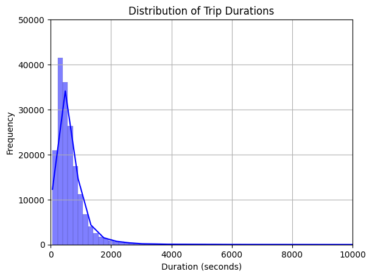

```python
# Plot histogram for duration_sec attribute
sb.histplot(bike_data_df['duration_sec'], bins=500, kde=True, color='blue')
plt.title('Distribution of Trip Durations')
plt.xlabel('Duration (seconds)')
plt.ylabel('Frequency')
plt.grid(True)
plt.axis([0, 10000, 0, 50000])

plt.show()
```

> To zoom in the plot and because the The distribution exhibits a long tail so will ue the log to let us see the visualization better

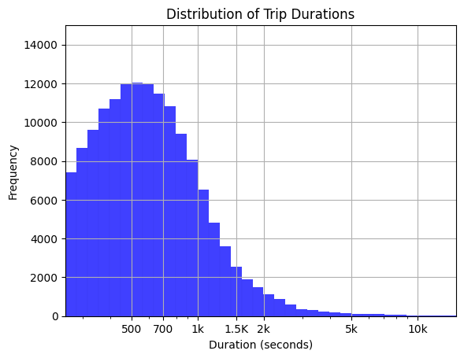

```python
bins = 10 ** np.arange(2.4, np.log10(bike_data_df['duration_sec'].max()) + 0.05, 0.05)

sb.histplot(bike_data_df['duration_sec'], bins=bins,  color='blue')
plt.title('Distribution of Trip Durations')
plt.xlabel('Duration (seconds)')
plt.ylabel('Frequency')
plt.grid(True)
plt.xscale('log')
plt.xticks([0,500, 700, 1e3,15e2, 2e3, 5e3, 1e4], [0,500,700, '1k','1.5K', '2k', '5k', '10k'])
plt.axis([0, 15000, 0, 15000])
plt.figure(figsize=[10, 10])

plt.show()
```

> The x-axis represents the duration of trips, while the y-axis shows the frequency of trips. From the previous histogram plots we can see that Most trips have a duration under 2,000 seconds that approximately 33 minutes, and we can see also that there is a peek around 600 seconds which indicates that there are significant number clustering around shorter durations (the majority of trips have shorter durations).

> As the duration increases, the frequency of trips decreases rapidly, resulting in a long tail to the right. Also the long tail indicates that there may a special case with the bikes trips that may mean that the bikes has been not been used in this duration

> Now I will analyze the distribution for the member_birth_year attribute that is one of the secondary attributes for the study

#### member_birth_year

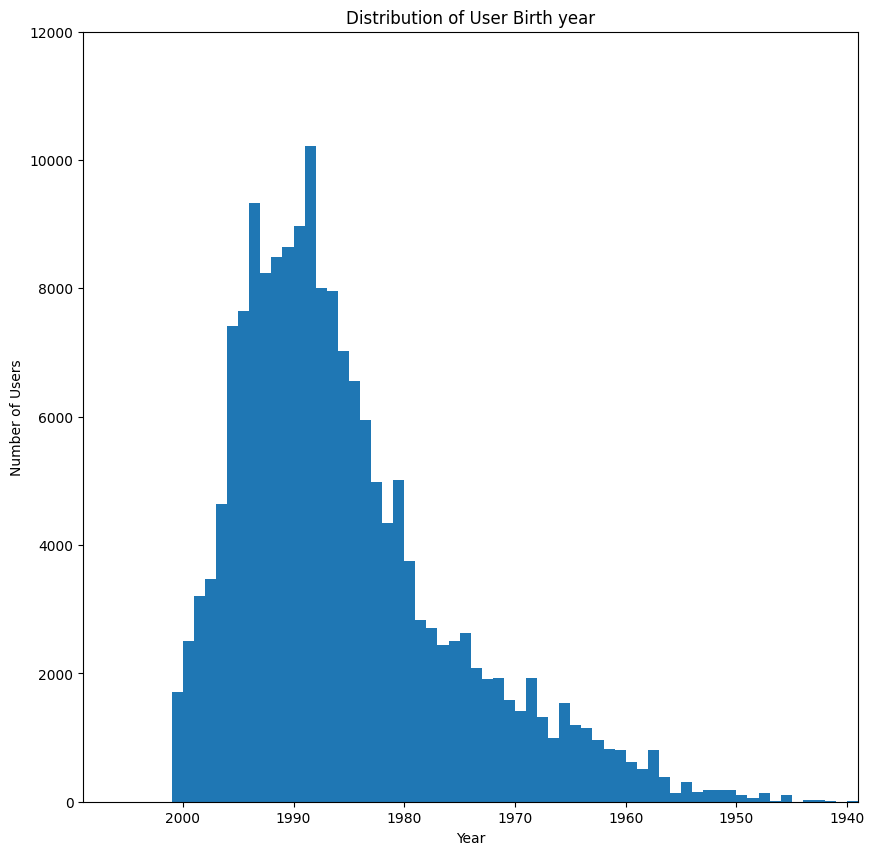

```python
# Plotting age distribution derived from member's birth year.

bins = np.arange(0, bike_data_df['member_birth_year'].astype(float).max()+1, 1)

plt.figure(figsize=[10, 10])
plt.hist(data = bike_data_df, x = 'member_birth_year', bins = bins)
plt.axis([1939, 2009, 0, 12000])
plt.gca().invert_xaxis()
plt.title('Distribution of User Birth year')
plt.xlabel('Year')
plt.ylabel('Number of Users')
plt.show()
```

> This histogram shows the distribution of users by their birth year. The x-axis represents the birth years, ranging from the 1940s to the early 2000s, and the y-axis indicates the number of users born in each year. The data suggests that the majority of users were born between 1980 and 2000, with a peak around the early 1990s. As the birth year moves away from this range, both earlier and later, the number of users decreases significantly.

> Now I will analyze the start_Station and end_Station attributes that are also a secondary attributes

#### Start Station

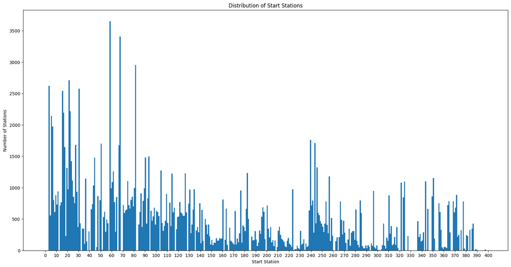

```python
# Plotting a Histogram for the start id Station
bins = np.arange(0, bike_data_df['start_station_id'].astype(float).max()+1, 1)

plt.figure(figsize=[20, 10])
plt.xticks(range(0, 402, 10))
plt.hist(data = bike_data_df.dropna(), x = 'start_station_id', bins = bins)
plt.title('Distribution of Start Stations')
plt.xlabel('Start Station')
plt.ylabel('Number of Stations')
plt.show()
```

#### End Station

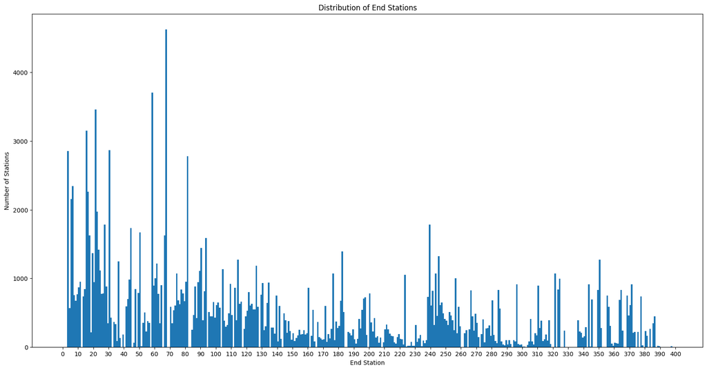

```python
# Plotting a Histogram for the end id Station
bins = np.arange(0, bike_data_df['end_station_id'].astype(float).max()+1, 1)
plt.figure(figsize=[20, 10])
plt.xticks(range(0, 402, 10))
plt.hist(data = bike_data_df.dropna(), x = 'end_station_id', bins = bins)
plt.title('Distribution of End Stations')
plt.xlabel('End Station')
plt.ylabel('Number of Stations')
plt.show()
```

> The previous Two plots that describe the distribution for the start and the end Station are the same and we can see that the bars vary in height, suggesting that some end stations have significantly more trips than others. Several peaks exist, with certain stations having over 3000 trips. Conversely, many stations have fewer than 500 trips.

### Count Plot

> Now I will analyze the user_type attribute that is one of the main features

#### user_type attribute

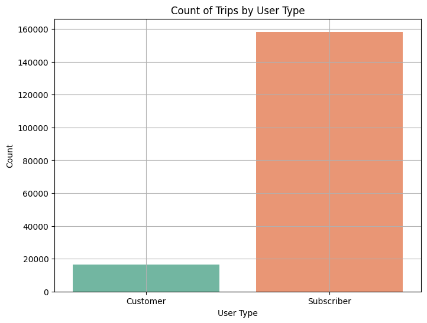

```python
# Plot the count plot for user type
plt.figure(figsize=(8, 6))
sb.countplot(x='user_type', data=bike_data_df, palette='Set2')
plt.title('Count of Trips by User Type')
plt.xlabel('User Type')
plt.ylabel('Count')
plt.grid(True)
plt.show()
```

> From the previous plot that shows the number of trips taken by different user types, we can see that there two types os users (Customer and Subscriber), and the plot indicates that the Subscriber type has higher counts of trips compared to the Customer type

#### Bar Chart

> For the Bar Chart I will first analyze user_type attribute and then member_gender attribute

#### User_type

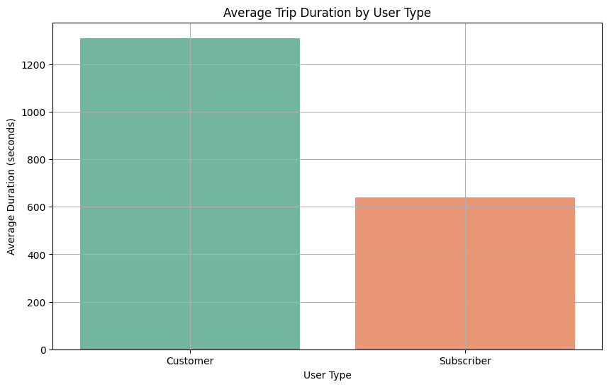

```python
# Bar Chart 1: Average Trip Duration by User Type
plt.figure(figsize=(10, 6))
avg_duration_by_user_type = bike_data_df.groupby('user_type')['duration_sec'].mean().reset_index()
sb.barplot(x='user_type', y='duration_sec', data=avg_duration_by_user_type, palette='Set2')
plt.title('Average Trip Duration by User Type')
plt.xlabel('User Type')
plt.ylabel('Average Duration (seconds)')
plt.grid(True)
plt.show()
```

> The Plot shows the relation between the user type and the average duration, and it show that the trip duration for Customers is significantly high, in contrast, Subscribers, who are regular users, tend to take shorter trips. The difference in trip duration reflects distinct usage patterns

#### Member_gender

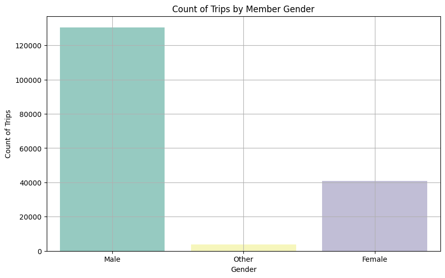

```python
# Bar Chart 2: Count of Trips by Member Gender
plt.figure(figsize=(10, 6))
sb.countplot(x='member_gender', data=bike_data_df, palette='Set3')
plt.title('Count of Trips by Member Gender')
plt.xlabel('Gender')
plt.ylabel('Count of Trips')
plt.grid(True)
plt.show()
```

> The chart reveals the distribution of bike-sharing usage across different genders, the chart shows that the male gender have higher count of trips compared to Female and other users that did not give their gender

### Discuss the distribution(s) of your variable(s) of interest. Were there any unusual points? Did you need to perform any transformations?

> For the duration_sec attribute histogram plot There are some outliers on the far right side of the histogram, indicating unusually long trip durations. These could represent cases where users kept the bikes for extended periods, possibly due to some reason. The sharp drop-off after 1,500 seconds shows that such long trips are relatively rare, suggesting that most users utilize the bike-sharing service for shorter commutes or recreational rides.

> The histogram for member_birth_year attribute, The most noticeable feature is the sharp spike around the early 1990s, where the number of users significantly increases compared to surrounding birth years. There don't appear to be clear outliers in the birth years themselves, but the tapering towards the extremes (especially users born before the 1960s) could be viewed as unusual when compared to the bulk of users being younger

### Of the features you investigated, were there any unusual distributions? Did you perform any operations on the data to tidy, adjust, or change the form of the data? If so, why did you do this?

> For the duration_sec attribute has the histogram plot values has been calculated using log for better visualization and for better insight into the feature

## Bivariate Exploration

### Scatterplot

> For the Scatter Plot I will first analyze member_birth_year attribute and it relation with trip duration

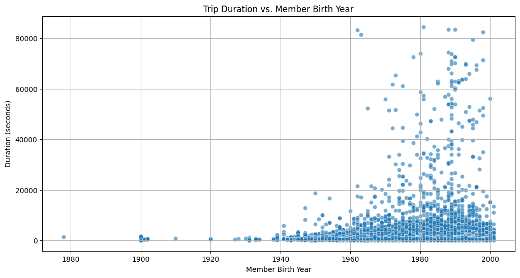

```python
# Scatterplot: Relationship between trip duration and member birth year
plt.figure(figsize=(12, 6))
sb.scatterplot(x='member_birth_year', y='duration_sec', data=bike_data_df, alpha=0.6)
plt.title('Trip Duration vs. Member Birth Year')
plt.xlabel('Member Birth Year')
plt.ylabel('Duration (seconds)')
plt.grid(True)
plt.show()
```

> The scatter plot shows the relation between the member's birth year and the duration of the trips, and we can see from the plot that the relation between the two attributes are not strong but we can indicate that there a diversity range of trip durations across different age groups. and we can see also that the The majority of the data points are concentrated between birth years 1950 and 2000.

### Box Plot

> For Box Plot, First I will analyze the relationship between the two attributes user_type and trip duration

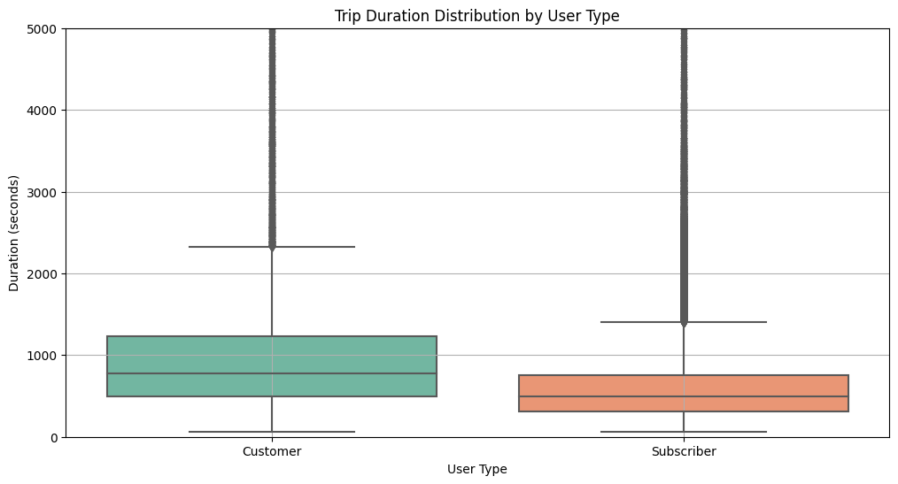

```python
# Box Plot: Distribution of trip durations across different user types
plt.figure(figsize=(12, 6))
sb.boxplot(x='user_type', y='duration_sec', data=bike_data_df, palette='Set2')
plt.title('Trip Duration Distribution by User Type')
plt.xlabel('User Type')
plt.ylabel('Duration (seconds)')
plt.grid(True)
plt.ylim(0, 5000)
plt.show()
```

> This box plot shows the distribution of trip durations in seconds for two user types: Customers and Subscribers. It compares the central tendency and spread of trip durations for each group, highlighting key differences in usage patterns.

> This box plot shows the distribution of trip durations for different user types (Customer and Subscriber). The plot reveals that Customers tend to have a wider range of trip durations, with several outliers indicating longer trips. On the other hand, Subscribers generally have shorter trips, as indicated by the median and interquartile range. The presence of outliers for both groups suggests that some users might be taking exceptionally long trips.

> For the second Box Plot I will analyze the relationship between the two attributes member_gender and trip duration

#### member_gender

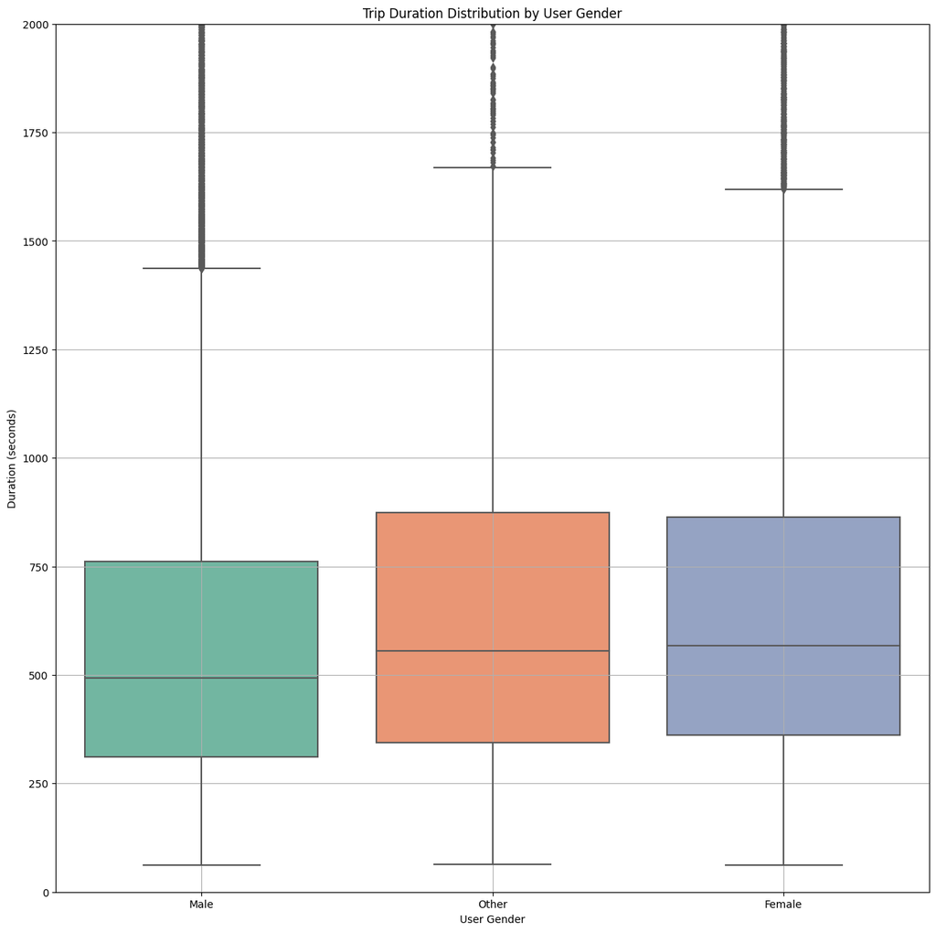

```python
# Box Plot: Distribution of trip durations across different member_gender
plt.figure(figsize=(15, 15))
sb.boxplot(x='member_gender', y='duration_sec', data=bike_data_df, palette='Set2')
plt.title('Trip Duration Distribution by User Gender')
plt.xlabel('User Gender')
plt.ylabel('Duration (seconds)')
plt.grid(True)
plt.ylim(0, 2000)
plt.show()
```

### Clustered Bar Chart

> I will analyze the relation between the count of trips by user type and member gender

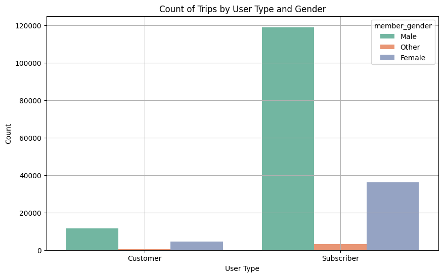

```python
# Clustered Bar Chart: Count of trips by user type and member gender
plt.figure(figsize=(10, 6))
sb.countplot(x='user_type', hue='member_gender', data=bike_data_df, palette='Set2')
plt.title('Count of Trips by User Type and Gender')
plt.xlabel('User Type')
plt.ylabel('Count')
plt.grid(True)
plt.show()
```

### Did you observe any interesting relationships between the other features (not the main feature(s) of interest)?

> The user gender and the user type and the number of trips have a relationships between them, when the user type is subscriber and the gender is male the number of trip is high

## Multivariate Exploration

### Face Plot

> First in Face Plot I will analyze the plot for Trip Duration vs. Member Birth Year by User Type

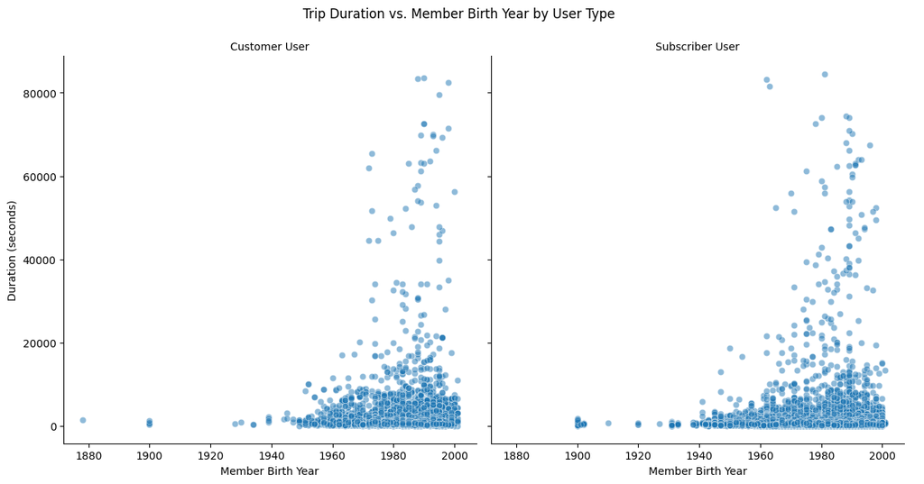

```python
# Facet Plot: Relationship between trip duration and member birth year by user type
facet = sb.FacetGrid(bike_data_df, col="user_type", height=6, aspect=1)
facet.map(sb.scatterplot, "member_birth_year", "duration_sec", alpha=0.5)
facet.set_axis_labels("Member Birth Year", "Duration (seconds)")
facet.set_titles(col_template="{col_name} User")
facet.figure.suptitle('Trip Duration vs. Member Birth Year by User Type', y=1.05)
facet.add_legend()
plt.show()
```

> This scatterplot shows the relationship between trip duration (in seconds) and the member's birth year for both user type (Customer and Subscriber). The x-axis represents the birth year of the members, ranging from the late 1800s to around 2000, while the y-axis shows the duration of trips. The plot shows that members for both user types born after 1940 have a higher concentration of trips with varying durations. As birth years approach 2000, the spread of trip durations increases, indicating a wider range of trip lengths among younger members. The data suggests that younger members are more likely to take longer trips, while older members tend to have shorter and more consistent trip durations. The presence of some outliers with extremely long durations, particularly among younger members, is also notable.

> Now I will examine the Face plot Trip Duration, Gender, and Age

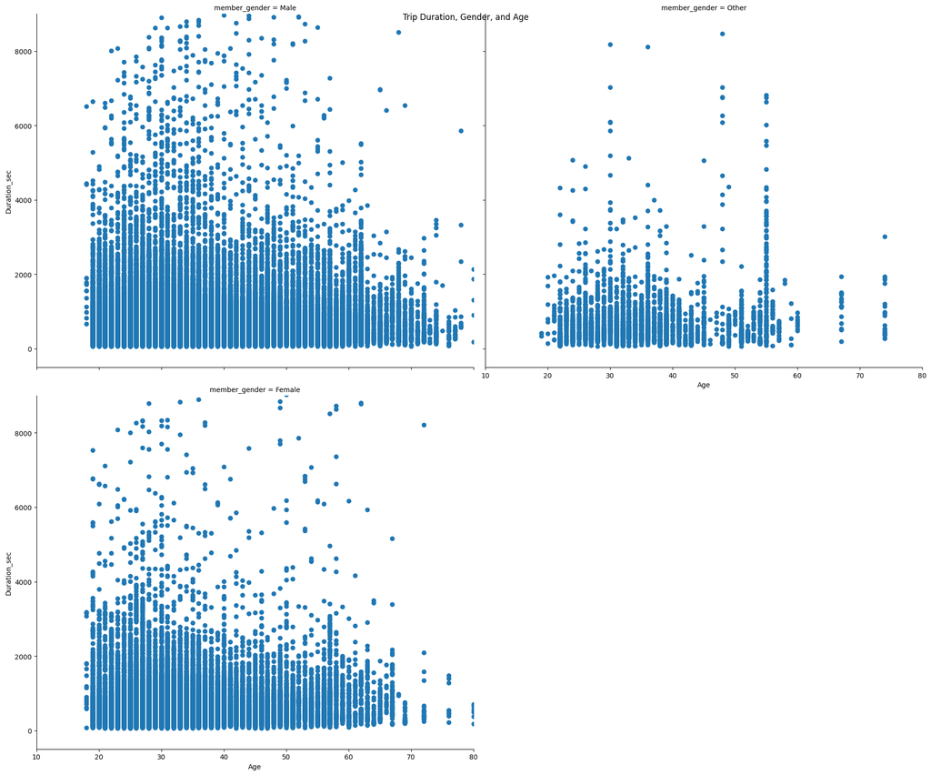

```python
#Plot the Face Plot for trip Duration, Gender, and Age
#Calculate the age by subtracting 2019 and the user year of birth
#the data set has been collected 2019 so that I used 2019
bike_data_df['age'] = (2019 - bike_data_df['member_birth_year'])
facePlot = sb.FacetGrid(data = bike_data_df, col = 'member_gender', col_wrap = 2,
                        height=8, aspect=1.2,
                 xlim = [10, 80], ylim = [-500, 9000])
facePlot.map(plt.scatter, 'age', 'duration_sec', alpha= 1)
facePlot.set_xlabels('Age')
facePlot.set_ylabels('Duration_sec')
facePlot.figure.suptitle('Trip Duration, Gender, and Age')

plt.show()
```

> Now I will analyze the relation between the duration_sec and age for each user type

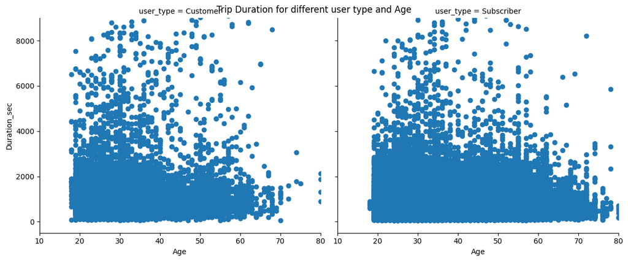

```python
#Plot the relation between the duration_sec and age for each user type
facePlotUserType = sb.FacetGrid(data = bike_data_df, col = 'user_type', col_wrap = 2,
                 xlim = [10, 80], ylim = [-500, 9000],height=5, aspect=1.2)
facePlotUserType.map(plt.scatter, 'age', 'duration_sec', alpha= 1)

facePlotUserType.set_xlabels('Age')
facePlotUserType.set_ylabels('Duration_sec')
facePlotUserType.figure.suptitle('Trip Duration for different user type and Age')
plt.show()
```

### Scatterplot

> Here I will plot and analyze the Scatter Plot for the Trip Duration vs. Member Birth Year for different user types

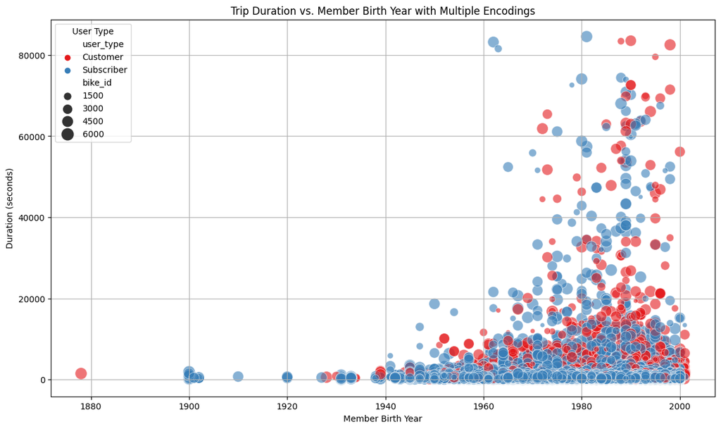

```python
# Plot Scatterplot with multiple encodings
plt.figure(figsize=(14, 8))
scatterPlot = sb.scatterplot(x='member_birth_year', y='duration_sec', hue='user_type',
size='bike_id', data=bike_data_df, palette='Set1', sizes=(20, 200), alpha=0.6)

plt.title('Trip Duration vs. Member Birth Year with Multiple Encodings')
plt.xlabel('Member Birth Year')
plt.ylabel('Duration (seconds)')
plt.legend(title='User Type')
plt.grid(True)
plt.show()
```

> This scatterplot visualizes the relationship between trip duration (in seconds) and the birth year of users for a bike-sharing dataset. Multiple encodings are used to distinguish between different user types and bike IDs. The x-axis represents the member birth year, and the y-axis shows the trip duration. The color of the dots indicates the user type, with red for customers and blue for subscribers. Additionally, the size of the dots represents the bike ID, with larger dots corresponding to higher bike IDs.The plot shows that most of the data points are clustered between birth years 1950 and 2000. There some outliers for older birth years. Also the plot shows that subscribers are the predominant user type in the dataset.

### Talk about some of the relationships you observed in this part of the investigation. Were there features that strengthened each other in terms of looking at your feature(s) of interest?

> Age and user type seem to strengthen each other when looking at trip duration. Younger customers tend to have longer trips, especially compared to subscribers, indicating that the type of user (whether they are subscribed or just one-time customers) has a significant impact on how long they tend to use the service. The distribution of trip durations by gender is fairly consistent, with slight variations. The key observation is that males and females mostly engage in shorter trips, but there is more variability in the "Other" gender category, indicating that gender identity may influence trip behavior in ways that are less predictable

## Conclusions

> Most users are aged between their 20s and 40s, with a strong concentration of users born in the early 1990s. Older and younger age groups are underrepresented, suggesting the bike trip is most popular among younger adults.

> Customers generally have longer and more varied trip durations, while subscribers tend to have shorter, more consistent trips. This suggests that subscribers may have regular trips.

> Male subscribers take over most of the trips's, making the majority of trips, followed by female subscribers. Customers of all genders account for significantly fewer trips compared to subscribers.